# Assessing the volatility within the South African bond markets, using GARCH modelling

Abstract

This article examines the volatility of the South African bond market. The article illustrates the various methods for measuring volatility by implementing the GARCH and DCC-GARCH models. The article concludes that short- to medium-term SA bonds are more volatile than long-term bonds. Bond yields in developing countries are often higher than those in developed economies. This might be a result of excessive repayment costs, stagnant economic development, and ineffective fiscal and monetary policy execution. In general, bond markets are critical for developing countries because they offer a source of revenue while also allowing the Reserve Bank to exert control over the money supply and consumer demand. Additionally, variables affecting bond market volatility include inflation, currency exchange rates, and economic development. However, modeling the noise is challenging due to the existence of other variables affecting bond yields. The article concludes that the GARCH and DCC-GARCH models are effective in removing noise from volatility presentation. Additionally, the 10-year bond yield exhibits consistency in its returns, corroborating the literature’s assertion that short- to medium-term rates are more volatile. Additional study should include a comparison of volatility to that of other developed countries and an analysis of the effect of exchange rate and inflation volatility on bond rates.

# **Introduction**

A government bond is a debt-based investment in which people acquire the bonds in exchange for a loan from the government. The exchange represents a guaranteed investment at a predetermined rate of return. These bonds are used by the government to pay off debt and fund projects Meyer and Hassan (2020). Numerous factors influence the yield rate. Firstly, supply and demand in the bond market — investors want low-risk, high-return bonds. Secondly, interest rates’ movement and level; a high interest rate above the bond yield results in poor demand for the bond. Thirdly, credit ratings; although bonds are low-risk investments, governments may fail, resulting in a credit deterioration. The primary objective of the South African (SA) bond market is to provide financing for development projects and debt reduction. Access to global financial markets, government risk levels, and currency rate volatility all contribute to the market’s development. These variables are heavily impacted by how the foreign community views the country’s economy. It is critical for the country’s bond market to be efficient since it offers an extra source of revenue and reduces the economy’s need for money. In times of economic expansion, inflation may rise, prompting the central bank to raise interest rates, resulting in higher bond yields. Investors want greater yields before investing as a consequence of the pressure exerted on the bond market by rising inflation rates.

Reasons for the research include the fact that the SA market is appealing since it serves as a proxy for emerging nations and accounts for a significant portion of the market. The paper is important because it looks into the volatility in the South African bond market, which could help policy-makers stabilize the economy, governance, and politics to keep the bond market stable. The bond market is critical for funding debt and infrastructure development; a healthy bond market allows fiscal and monetary expansion. Therefore the study is significant as literature has shown a direct relationship between changes in bond market yields and economic growth. As well as the relationship between bond market yields, effective governance, and interest rates.

In light of the above, the primary objective of this paper is to analyse SA’s bond market volatility, placing focus on its 3 month, 2 year and 10 year bond yields respectively.

In summarising the main findings of this paper:

- The data shows a virtual relationship between the SA bond yields, the inflation rate, volatility index and the exchange rate. This is in line with literature.
- The period of the 2000s, the aftermath of the dot.com bubble, the financial crisis 2007/8 and the 2019 pandemic, contain the highest rate of volatility.
- The GARCH and DCC-GARCH account for the noise in volatility.

The rest of the paper is structured as follows. The data section provides a description of the dataset used in this paper. Thereafter, the structure and rationale related to the application of the GARCH and the DCC-GARCH framework in volatility analysis is discussed throughout the section Methodology section. The empirical findings from the model are discussed in the preceding sections, before presenting concluding remarks.

# **Data**

Lastly, the US and SA exchange rates are shown in Figure 4. Meyer (2020) explains that the worsening volatility of African countries’ exchange rates has contributed adversely to bond yields. His paper finds that the exchange rate volatility is one of the limiting factors of the economy’s bond market as it discourages foreign investment into the market Meyer and Hassan (2020). The figure shows that high/spikes of the exchange rate in the early 2000s, 2010s and 2019 are similar to that represented in the volatility index and inflation prices.

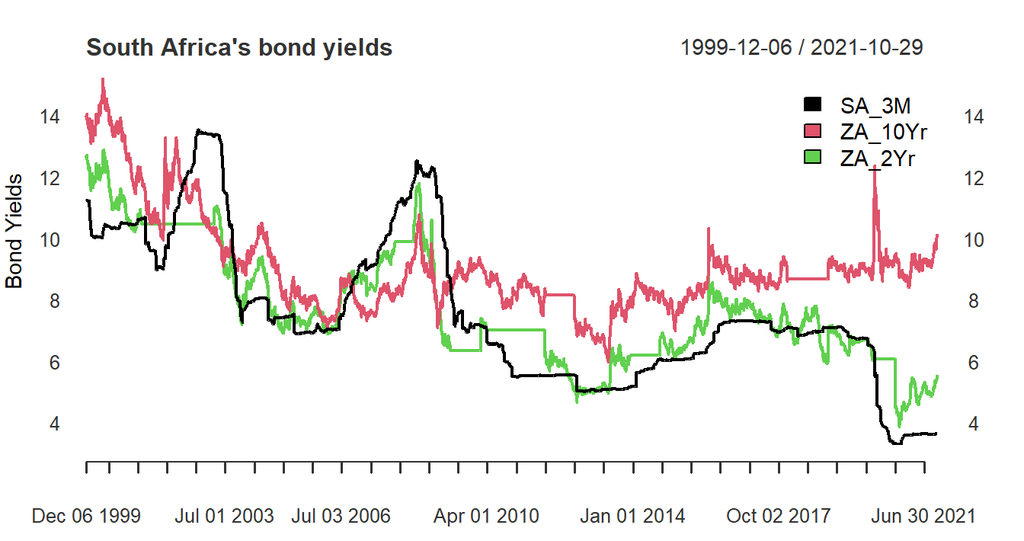

Figure 1 South African bond yields

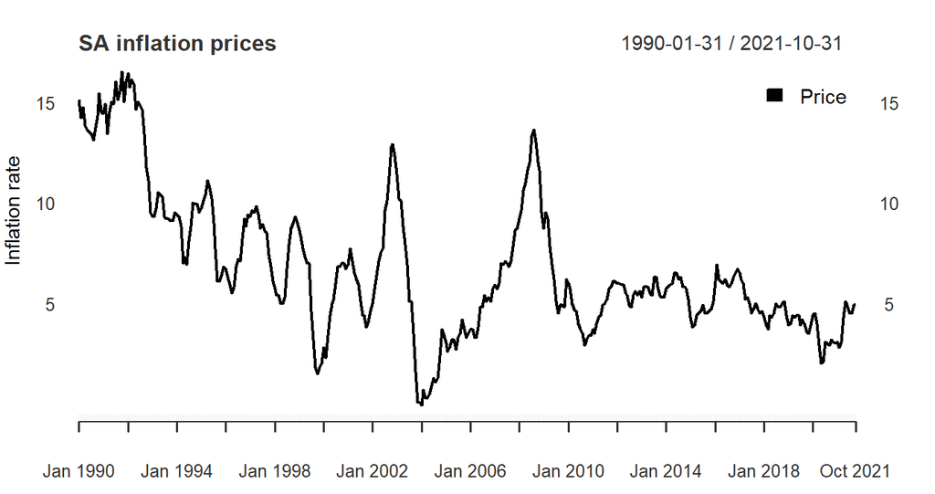

Figure 2 South African inflation prices

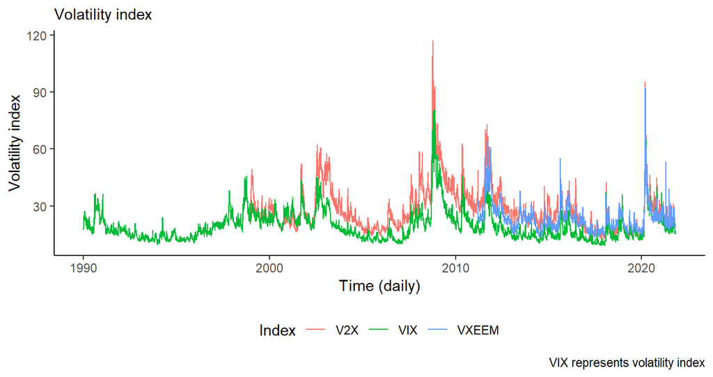

Figure 3 Volatility index

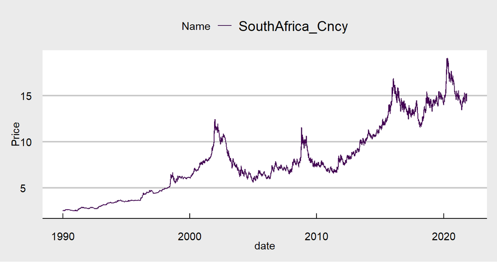

Figure 4 ZAR and USD exchange rate

### Bond yields

The yield of a bond represents the money lent. The higher the yield, the higher the return on the investment. Figure 1 shows SA bond yields for the 3 months, 2 year and 10 year maturity. A significant decline is seen during 2008 financial crisis as well as during 2020 as caused by the COVID-19 pandemic. However, one notices a rise in the mid and long term bonds, while the short term (3M) remains at a constant rate. Usually, yields with relative maturities move relatively close and may move together in the same fashion as seen in the diagram.

To compare the performance of SA 2 Year bond yields to that of the US, UK, Brazil and Nigeria, Figure 5 below shows this. The US and UK bond market tend to move with each other, while Nigeria’s bond yields are very high. In other words, the mid-term bond rate, the 2-year bond yield, shows South African yields higher than the United States (US), United Kingdom (UK) and Brazil. Nigeria has significantly higher yields. The graph shows that developed countries, the UK and the US, have lower bond yields than Nigeria, SA, and Brazil. Higher yields in developing countries may lead to higher costs on loans as the country may have higher risk ratings.

The graph indicates different volatility processes. A similar pattern is seen in the 10-year bond yields (Figure 6). The bond spread is seen in Figure 7, bond spreads show the difference in the 3 month and 2-year bond yields with the 10-year bond yield as the benchmark. A spread is used to calculate the value of one bond to another. It is the reflection of the relative risk of the bonds. Figure 7 indicates rising bond spreads from 2020, which might mean that bonds are riskier than usual. One notices that the spread moves in a similar pattern since the terms are similar (3M and 2Yr) and are affected by the general changes in the economy.

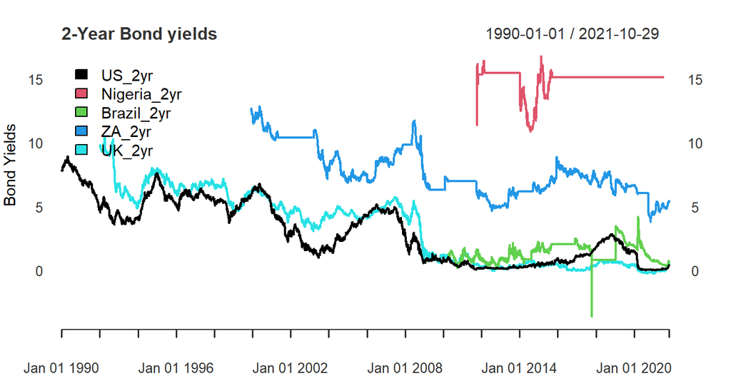

Figure 5 South African bond yields

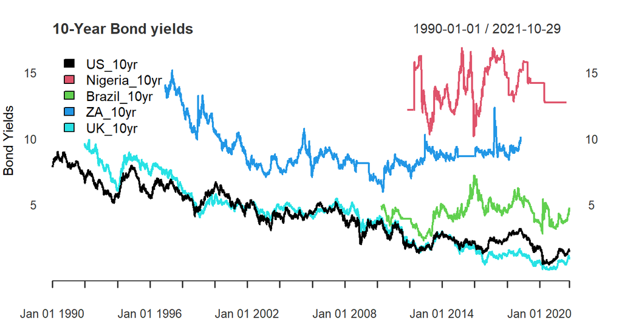

Figure 6 South African bond yields

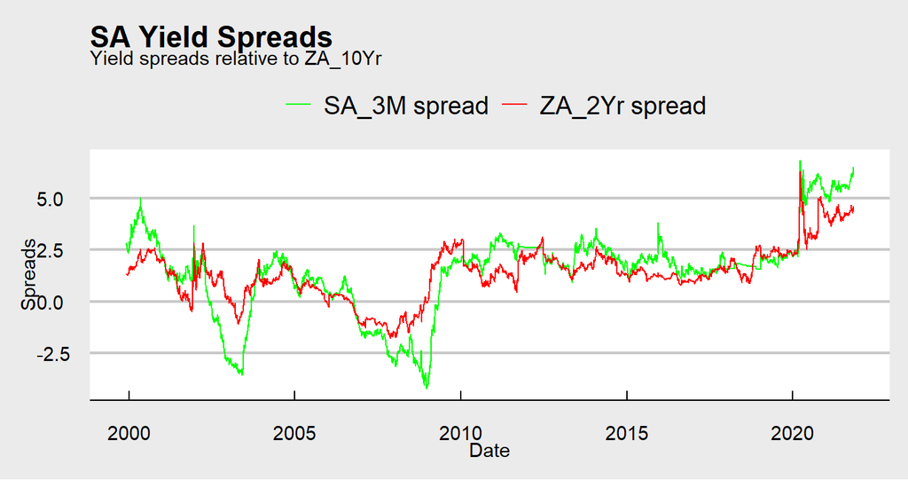

Figure 7 SA Yield Spreads

# **Methodology**

The GARCH model extends the (ARCH) Autoregressive Conditional Heteroskedasticity model. The GARCH model allows the variance to depend on its lags and squared residuals. The GARCH model cares for heteroscedasticity as a variance to be modelled. Heteroscedasticity is the presence of non-constant variance, which financial time series contain. The issues that arise when modelling volatility needs to be done as the most common method, the Ordinary Least Squares (OLS), may lead to misleading conclusions. Hence, the effectiveness of the GARCH model is that it accounts for heteroscedasticity, which corrects the shortcomings of the OLS model. Therefore, GARCH modelling is an essential element used to model volatility. However, one critic is that it models conditional variance as a linear function of the squared past values where a positive shock affects the volatility similarly to an adverse shock.

Firstly, volatility is investigated where the annualised volatility, the rolling month estimates and predictive errors are shown. Secondly, the differentiated yields are calculated and shown graphically, followed by the autocorrelation results. Thirdly, the Univariate GARCH model is analysed, followed by the multivariate GARCH model. The Multivariate DCC-GARCH model is analysed, and the plots for covariance and correlation are done based on this.

The GARCH: A Generalised Autoregressive Conditional Heteroskedasticity model is used to handle changing volatility in financial time series data. The equation below shows the popular GARCH form of the volatility process Tsay (2005). The equation means the current volatility is equal to the last day’s volatility and the last day’s return, with estimated parameters. This type of ARCH class of conditional volatility models allows heteroscedasticity in the regression. Heteroscedasticity is when the regression residual is not independent of the predictors. The DCC-GARCH is the Dynamic Conditional Correlation (DCC) GARCH model, and the DCC model estimates the correlation matrix directly through the use of standard residuals.

$$\begin{equation}
\sigma^2 = w + \alpha (\epsilon^2_{t-1} ) + (\beta) \sigma^2_{t-1}
\label{eq1}
\end{equation}$$
$$\begin{equation}
r_{t} = \mu + \epsilon_{t}
\label{eq2}
\end{equation}$$
$$\begin{equation}
\epsilon_{t} = \sigma_{t} . z_{t}
\label{eq3}
\end{equation}$$
$$\begin{equation}
\sigma^2 = \alpha + \beta_{1}\epsilon^2_{t-1} + \beta_{t}\sigma^2_{t-1}
\label{eq4}
\end{equation}$$
$$\begin{equation}
z_{t} = N (0,1)
\label{eq5}
\end{equation}$$

# 1. Volatility

## Annualised, rolling volatility and predictive errors

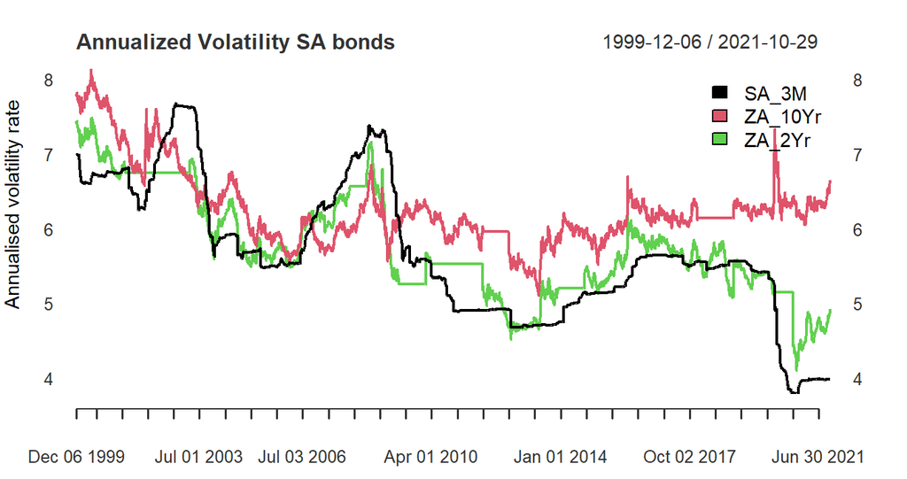

Figure 8 Annualised volatility rate

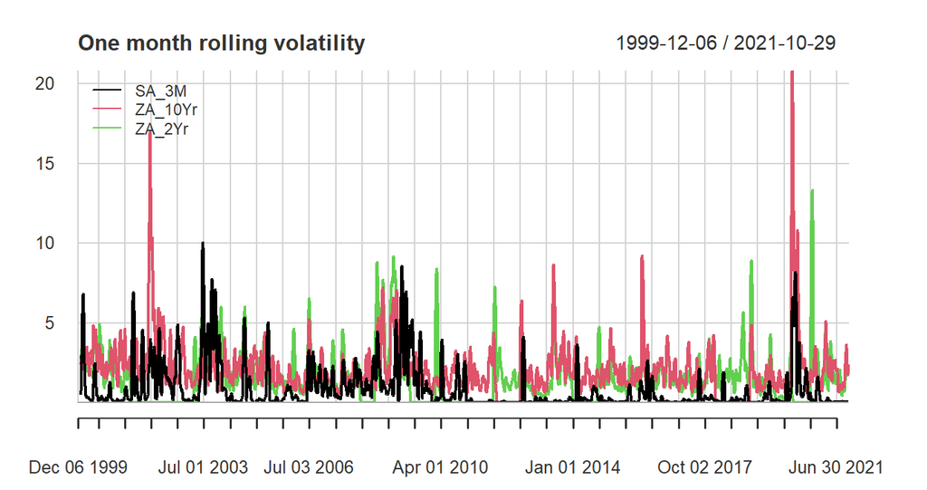

Figure 9 One month rolling volatility

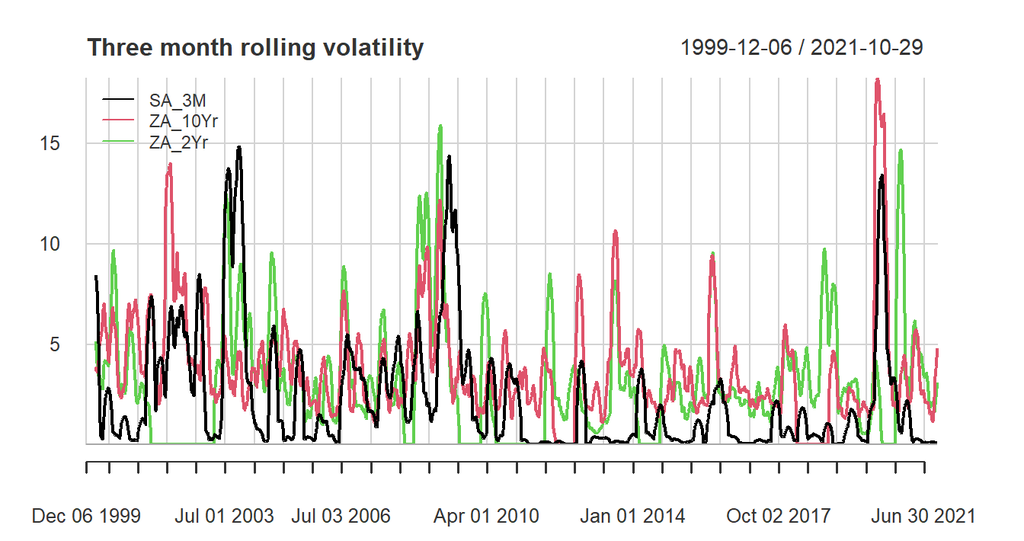

Figure 10 Three month rolling volatility

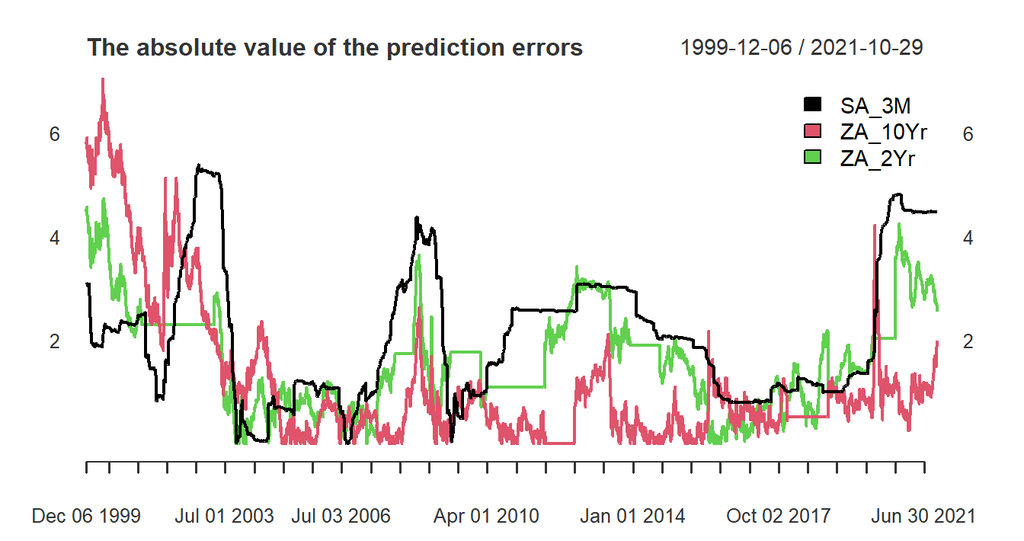

Figure 11 The absolute value of the prediction errors

## Differentiated bond yields and autocorrelation

Calculating the yield levels through “differentiation” allows us to make the time series independent of time. The calculation is the difference between the previous yield to the current yield. Figure 12 shows the yield changes by bond maturity date. One notes negative returns in the short term bond; much of the volatility clustering is seen in 2-year bonds during the early 2000s and 2020s. Volatility clustering is the behaviour of jagged peaks in the series. One notices periods of high and low volatility in the yield changes. The long term bond has mainly experienced positive change, and a negative dip is seen in the 2020s; this may have been due to the pandemic. Furthermore, short and mid-term are volatile mainly by observing the yield change; the 10-year bond holds its consistency over time.

Figure 12 shows the yield changes in the bond. The graph shows that the direction (positive or negative) is independent of the previous day’s returns. The magnitude of the return is similar to the previous day’s return. It shows that the expected return will be similar to a turbulent tomorrow during a volatile market or crisis. Significant yield changes tend to happen close to each other. This is known as volatility clustering.

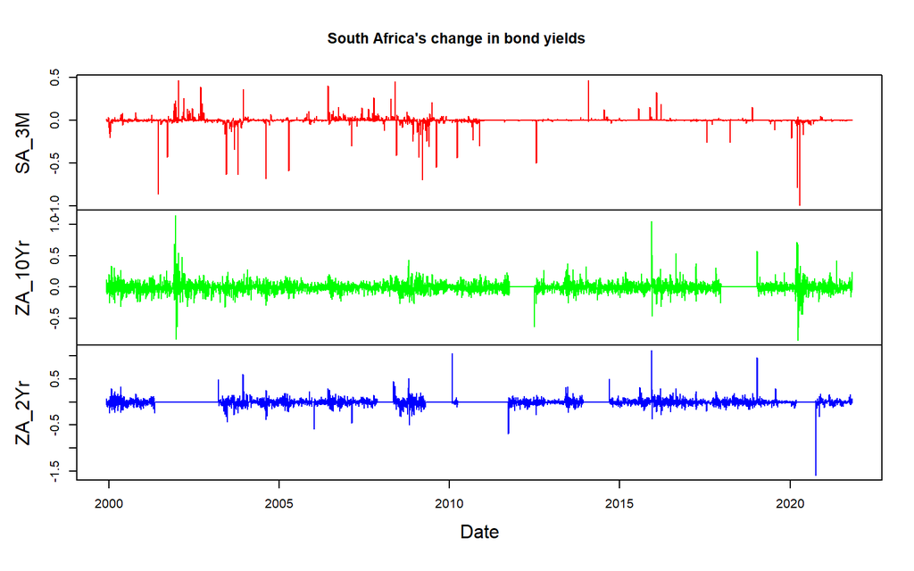

Figure 12 South Africa’s change in bond yields

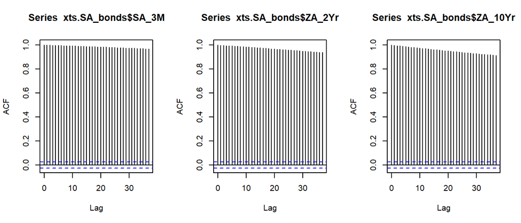

# 2. The GARCH model

The above analysis show a presence of volatility clustering, given this, the GARCH model is presented to capture the expected variance of the residuals from another model.

## Estimated Volatility and Residuals

Figure 14 - 16 shows the estimated volatility and residuals from the GARCH model. The figures show periods of high volatility during the 2007- 2009 periods and 2020. The 3 month and 2 year bond yields have residuals fluctuations whereas the 10 year bond yield is consistent showing little negative spikes.

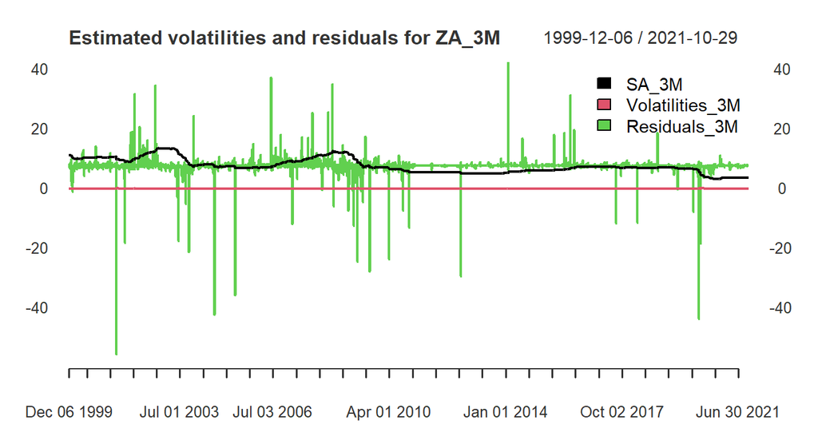

Figure 14 Estimated volatilities and residuals for ZA_3M

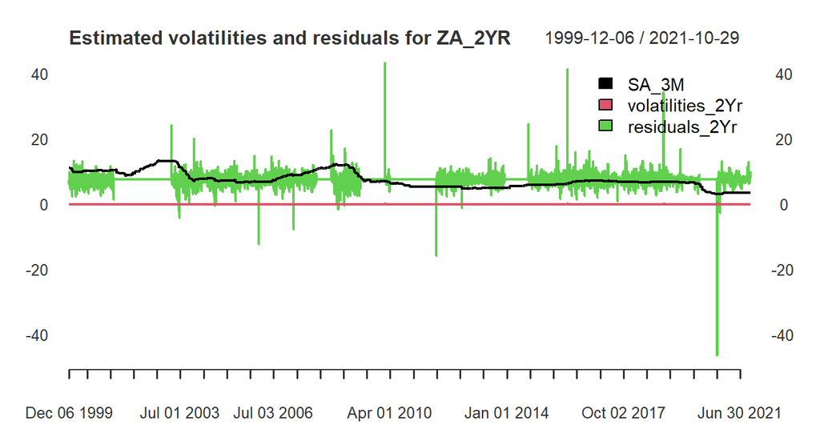

Figure 15 Estimated volatilities and residuals for ZA_2YR

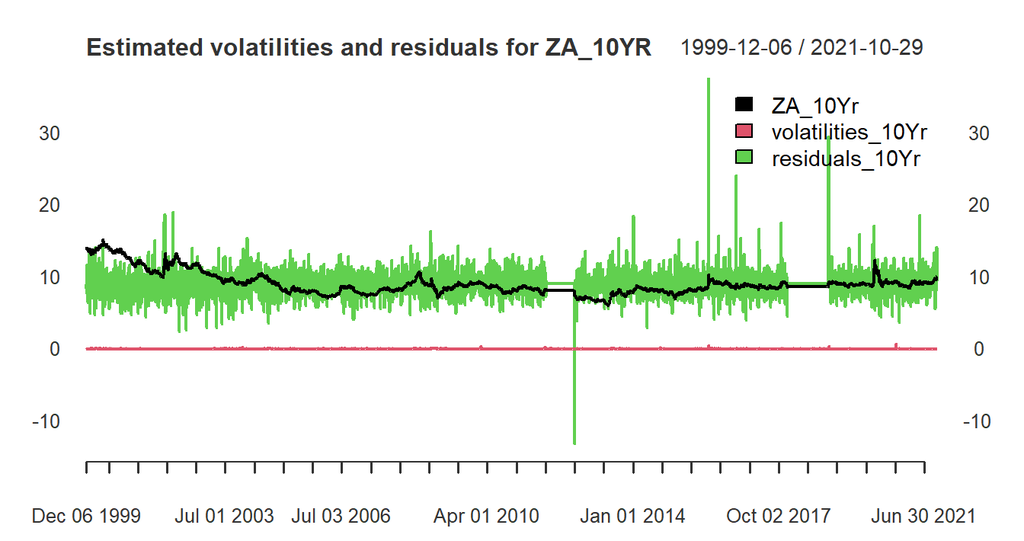

Figure 16 Estimated volatilities and residuals for ZA_10YR

## GARCH model specification

This is a standard GARCH (1,1); it does an excellent job dealing with second-order persistence. The weighted ARCH LM test works by regressing the squared errors on its lags and testing the hypothesis that all coefficients of the lagged regression are equal to zero. The Weighted ARCH LM tests show a high p-value. We do not reject the null hypothesis of no autocorrelation—the lower the p-value, the higher chance of finding the ARCH effect Perlin et al. (2020). Figure 13 showed high levels of autocorrelation. After implementing the GARCH, we have a lower p-value indicating that we do not reject the null hypothesis. The results of the GARCH model is found in the Appendix for all bond yield output.

### 3 Month SA bond yields

All coefficients are statistically significant. The mean equation is positive, implying that the 3-month bond yield is likely to have a positive return and increase its value in the long run. The sum of *alpha* and *beta* is 0.9664, less than 1 Perlin et al. (2020). The high values of the volatility parameters *alpha* and *beta* may reflect SA’s economy, the high degree of uncertainty and shock propagation. Conditional Variance plot using GARCH sigma eliminates the unnecessary noise (Figure 17). The red line is the actual volatility representation. Figure 18 is a representation of all the GARCH plots.

Model coefficients 3 Month

|  | Estimate | Std. Error | t value | Pr(>\|t\|) |
| --- | --- | --- | --- | --- |
| mu | 13.1397951 | 0.0058624 | 2241.349703 | 0 |
| ar1 | 0.9998894 | 0.0001178 | 8487.760224 | 0 |
| omega | 0.0001132 | 0.0000087 | 12.964395 | 0 |
| alpha1 | 0.0791106 | 0.0131697 | 6.006997 | 0 |
| beta1 | 0.8873634 | 0.0092627 | 95.800145 | 0 |

Information criteria

| Akaike | -3.616138 |
| --- | --- |
| Bayes | -3.610320 |
| Shibata | -3.616140 |
| Hannan-Quinn | -3.614113 |

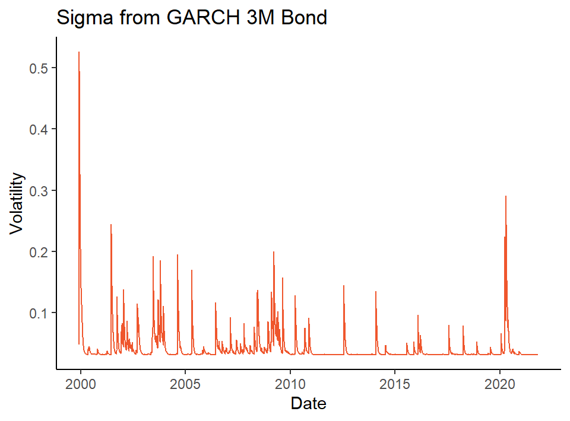

Figure 17 Sigma from GARCH 3M Bond

```
##
## please wait...calculating quantiles...
```

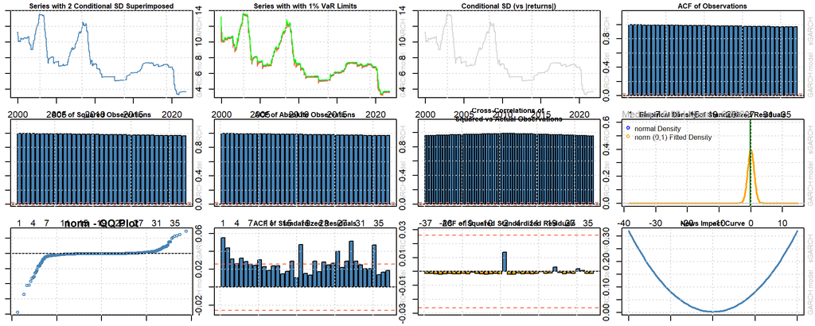

Figure 18 GARCH graph plots ZA_3M

### 2 Year SA bond yields

All coefficients are statistically significant. The mean equation is positive, implying that the 2-year bond yield is likely to have a positive return and increase its value in the long run. The sum of *alpha* and *beta* is 0.758, which is less than 1. The high values of the volatility parameters *alpha* and *beta* may reflect the SA’s economy, the high degree of uncertainty and shock propagation. Conditional Variance plot using GARCH sigma eliminates the unnecessary noise (Figure 19); the red line is the actual volatility representation. Figure 20 is a representation of all the GARCH plots.

Model coefficients 2Year

|  | Estimate | Std. Error | t value | Pr(>\|t\|) |
| --- | --- | --- | --- | --- |
| mu | 12.7430010 | 0.0617512 | 206.360270 | 0 |
| ar1 | 1.0000000 | 0.0001726 | 5793.388106 | 0 |
| omega | 0.0013384 | 0.0001428 | 9.370652 | 0 |
| alpha1 | 0.2115390 | 0.0245480 | 8.617360 | 0 |
| beta1 | 0.5470798 | 0.0429626 | 12.733864 | 0 |

Information criteria

| Akaike | -2.669806 |
| --- | --- |
| Bayes | -2.663987 |
| Shibata | -2.669807 |
| Hannan-Quinn | -2.667780 |

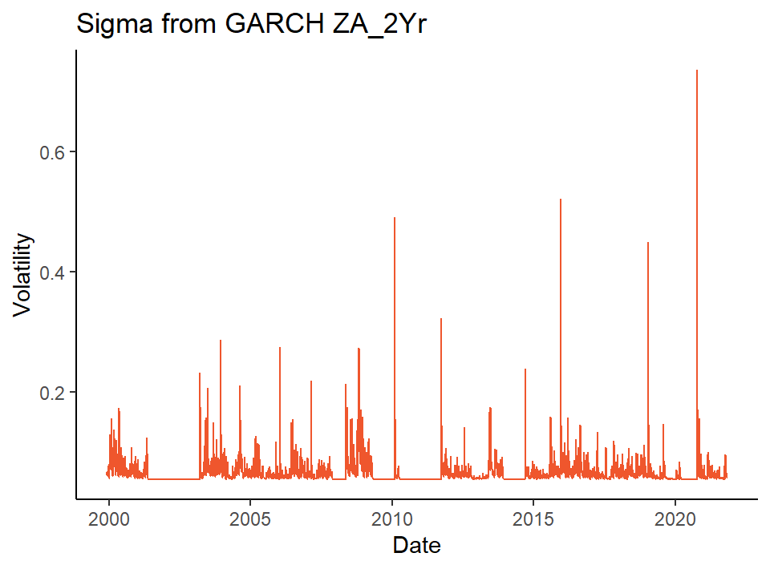

Figure 19 Sigma from GARCH 2yr

```
##
## please wait...calculating quantiles...
```

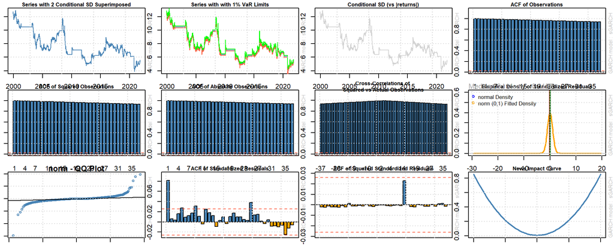

### 10 year SA bond yields

All coefficients are statistically significant. The mean equation is positive, implying that the 10-year bond yield is likely to have a positive return and increase its value in the long run. The sum of *alpha* and *beta* is 0.949. This is less than 1. The high values of the volatility parameters *alpha* and *beta* may reflect the SA’s economy, the high degree of uncertainty and shock propagation. Conditional Variance plot using GARCH sigma eliminates the unnecessary noise (Figure 21); the red line is the actual volatility representation. Figure 22 is a representation of all the GARCH plots.

Model coefficients 10Year

|  | Estimate | Std. Error | t value | Pr(>\|t\|) |
| --- | --- | --- | --- | --- |
| mu | 14.0320112 | 0.0776231 | 180.771028 | 0 |
| ar1 | 1.0000000 | 0.0001802 | 5549.601489 | 0 |
| omega | 0.0003582 | 0.0000399 | 8.970225 | 0 |
| alpha1 | 0.1382237 | 0.0144791 | 9.546445 | 0 |
| beta1 | 0.8115948 | 0.0170144 | 47.700537 | 0 |

Information criteria

| Akaike | -2.494491 |
| --- | --- |
| Bayes | -2.488672 |
| Shibata | -2.494492 |
| Hannan-Quinn | -2.492465 |

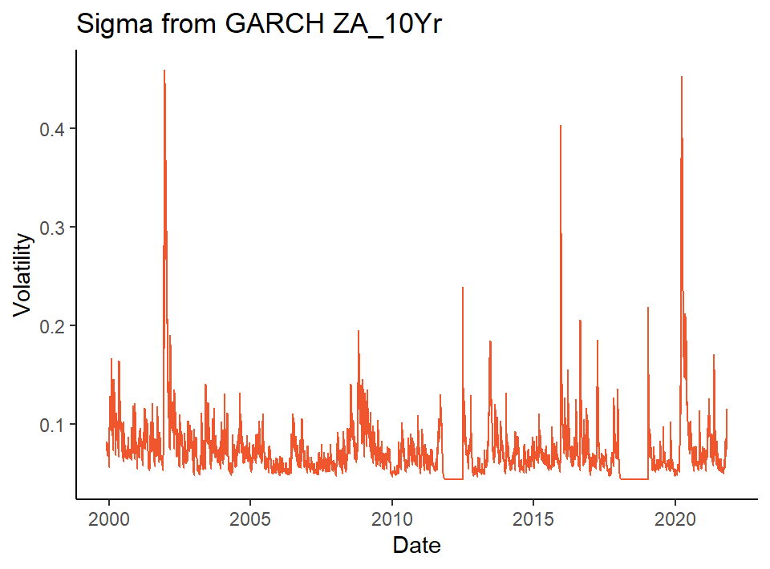

Figure 21 Sigma from GARCH 10Yr

```
##
## please wait...calculating quantiles...
```

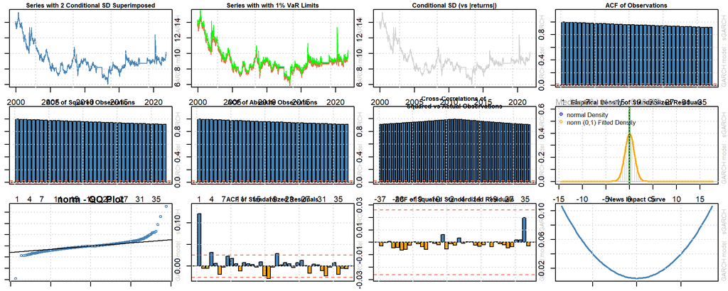

Figure 22 GARCH graph plots ZA_10Yr

# 3. The DCC-GARCH model

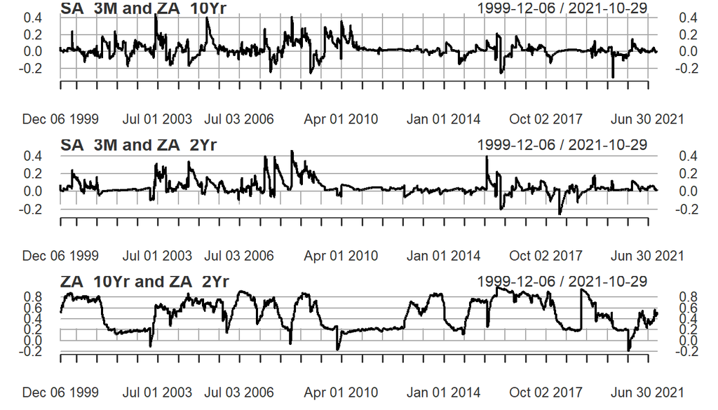

Figure 23 Correlation

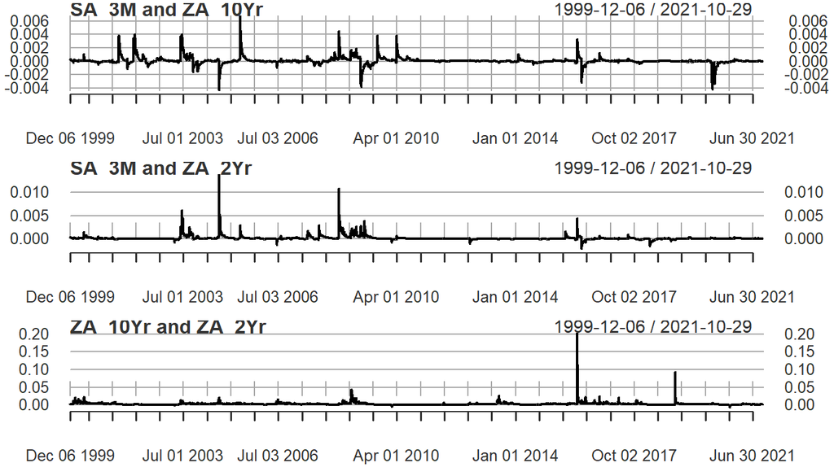

Figure 24 Covariance

### DCC Forecast

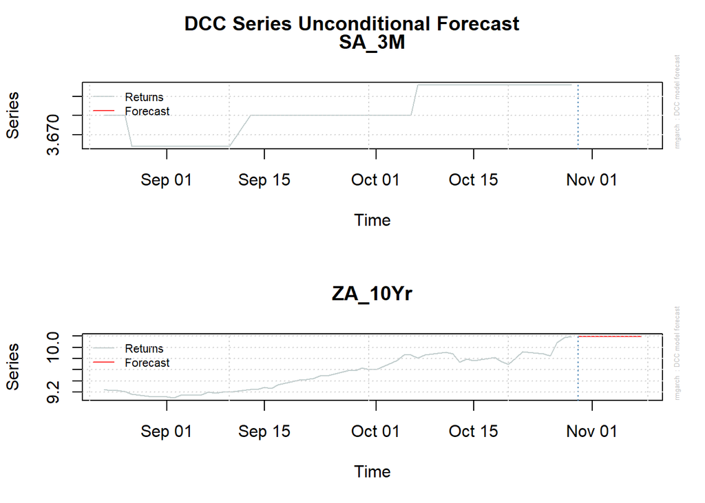

Figure 25 DCC Series Unconditional Forecast

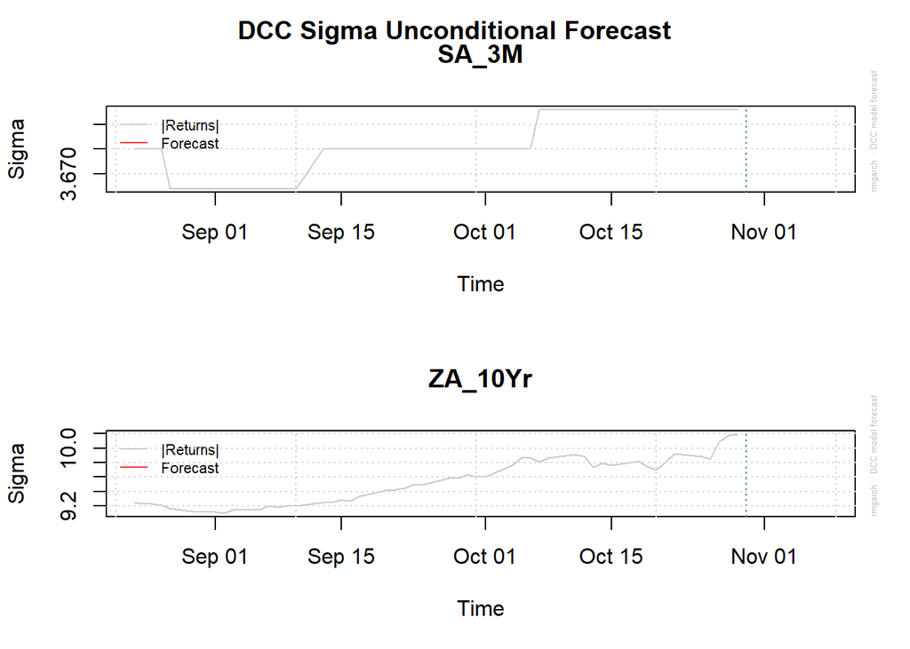

Figure 26 DCC Sigma Unconditional Forecast

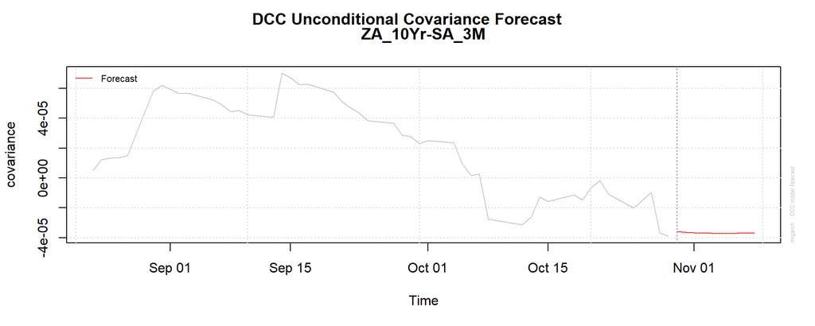

Figure 27 DCC Unconditional Covariance Forecast

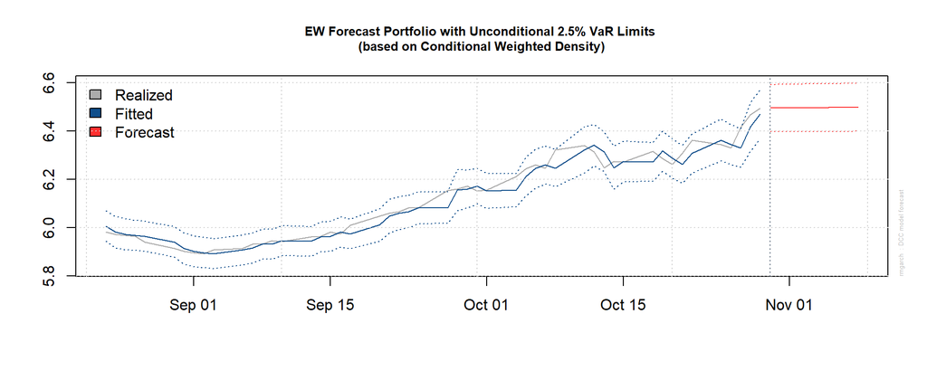

Figure 28 EW Forecast Portfolio with Unconditional limits

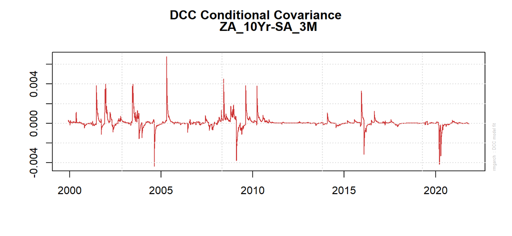

Figure 31 DCC Conditional Covariance

### Correlation and covariance forecast

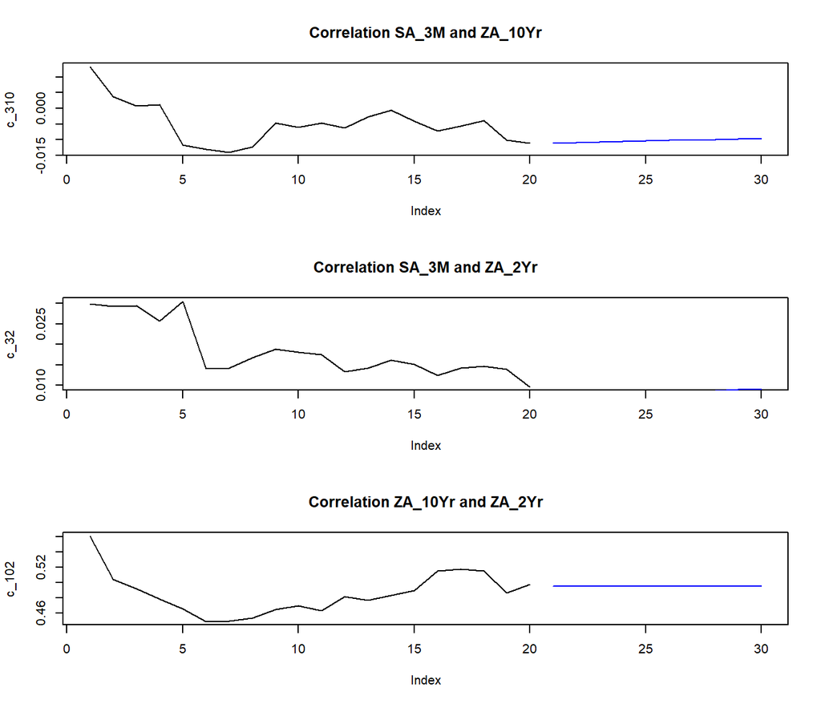

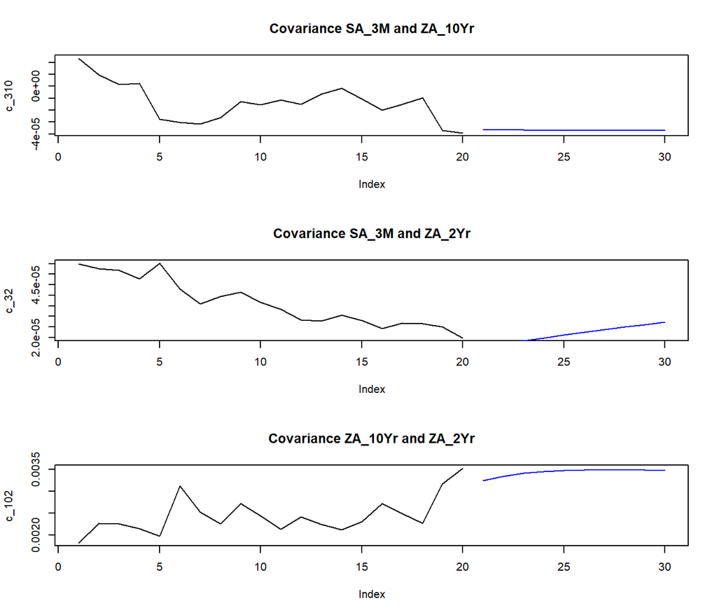

# **Conclusion**

This paper offers a perspective on volatility modelling for the SA bond market. Furthermore, this research focused on modelling volatility using the GARCH and DCC-GARCH models. The main findings uncovered in the paper suggest that bond yields tend to cluster during high volatile periods. These periods include the financial crisis and COVID-19; yields during volatile periods face a higher dependence on the previous yields. The GARCH and DCC-GARCH models smoother volatilities over time.

As such the bond market is significant for two reasons: it offers an extra income source and impacts consumer purchasing power. First, bond market volatility increases investor risk and affects SA’s sovereign debt markets and portfolio management. Second, a turbulent economy has a detrimental effect on the bond market, reducing the government’s capacity to service its debt. The paper’s weakness is that it does not directly compare South Africa’s volatility to other developed countries. Additional research may be conducted to model the volatilities in the US and the UK to establish an appropriate comparison. However, the figures indicate that developed country bond rates move similarly, although developing country bond yields tend to be higher. Therefore, further prediction and forecasting of the bond markets is necessary.

# **Appendix**

```
##
## *---------------------------------*
## *          GARCH Model Fit        *
## *---------------------------------*
##
## Conditional Variance Dynamics
## -----------------------------------
## GARCH Model  : sGARCH(1,1)
## Mean Model   : ARFIMA(1,0,0)
## Distribution : norm
##
## Optimal Parameters
## ------------------------------------
##         Estimate  Std. Error  t value Pr(>|t|)
## mu     13.139795    0.005862 2241.350        0
## ar1     0.999889    0.000118 8487.760        0
## omega   0.000113    0.000009   12.964        0
## alpha1  0.079111    0.013170    6.007        0
## beta1   0.887363    0.009263   95.800        0
##
## Robust Standard Errors:
##         Estimate  Std. Error  t value Pr(>|t|)
## mu     13.139795  154.196825 0.085214  0.93209
## ar1     0.999889    1.186271 0.842884  0.39929
## omega   0.000113    0.003421 0.033079  0.97361
## alpha1  0.079111    6.993656 0.011312  0.99098
## beta1   0.887363    4.513173 0.196616  0.84413
##
## LogLikelihood : 10338.12
##
## Information Criteria
## ------------------------------------
##
## Akaike       -3.6161
## Bayes        -3.6103
## Shibata      -3.6161
## Hannan-Quinn -3.6141
##
## Weighted Ljung-Box Test on Standardized Residuals
## ------------------------------------
```

[output cut: 40 more lines]

```
## Negative Sign Bias 0.68784 0.4916
## Positive Sign Bias 0.17016 0.8649
## Joint Effect       0.50220 0.9184
##
##
## Adjusted Pearson Goodness-of-Fit Test:
## ------------------------------------
##   group statistic p-value(g-1)
## 1    20     48791            0
## 2    30     72578            0
## 3    40     97053            0
## 4    50    121588            0
##
##
## Elapsed time : 0.8779988
```

[output not shown]

[output cut: 40 more lines]

```
## Negative Sign Bias 0.68784 0.4916
## Positive Sign Bias 0.17016 0.8649
## Joint Effect       0.50220 0.9184
##
##
## Adjusted Pearson Goodness-of-Fit Test:
## ------------------------------------
##   group statistic p-value(g-1)
## 1    20     48791            0
## 2    30     72578            0
## 3    40     97053            0
## 4    50    121588            0
##
##
## Elapsed time : 0.879333
```

[output not shown]

[output cut: 40 more lines]

```
## Negative Sign Bias 0.68784 0.4916
## Positive Sign Bias 0.17016 0.8649
## Joint Effect       0.50220 0.9184
##
##
## Adjusted Pearson Goodness-of-Fit Test:
## ------------------------------------
##   group statistic p-value(g-1)
## 1    20     48791            0
## 2    30     72578            0
## 3    40     97053            0
## 4    50    121588            0
##
##
## Elapsed time : 1.364002
```

```
##
## *----------------------------*
## *     GARCH Multi-Fit        *
## *----------------------------*
## No. Assets :3
## GARCH Multi-Spec Type : Equal
## GARCH Model Spec
## --------------------------
## Model : sGARCH
## Exogenous Regressors in variance equation: none
##
## Mean Equation :
## Include Mean :  1
## AR(FI)MA Model : (1,d,0)
## GARCH-in-Mean :  FALSE
## Exogenous Regressors in mean equation: none
## Conditional Distribution:  norm
##
## GARCH Model Fit
## --------------------------
## Optimal Parameters:
##               SA_3M    ZA_10Yr     ZA_2Yr
## mu         13.13980   14.03201   12.74300
## ar1         0.99989    1.00000    1.00000
## omega       0.00011    0.00036    0.00134
## alpha1      0.07911    0.13822    0.21154
## beta1       0.88736    0.81159    0.54708
## Log-Lik 10338.11571 7133.00753 7633.96942
```

```
##
## *---------------------------------*
## *          DCC GARCH Fit          *
## *---------------------------------*
##
## Distribution         :  mvnorm
## Model                :  DCC(1,1)
## No. Parameters       :  20
## [VAR GARCH DCC UncQ] : [0+15+2+3]
## No. Series           :  3
## No. Obs.             :  5715
## Log-Likelihood       :  25902.82
## Av.Log-Likelihood    :  4.53
##
## Optimal Parameters
## -----------------------------------
##                   Estimate  Std. Error    t value Pr(>|t|)
## [SA_3M].mu       13.139795   90.776241 1.4475e-01 0.884909
## [SA_3M].ar1       0.999889    0.698361 1.4318e+00 0.152211
## [SA_3M].omega     0.000113    0.002013 5.6208e-02 0.955176
## [SA_3M].alpha1    0.079111    4.114501 1.9227e-02 0.984660
## [SA_3M].beta1     0.887363    2.655654 3.3414e-01 0.738273
## [ZA_10Yr].mu     14.032011    0.000340 4.1287e+04 0.000000
## [ZA_10Yr].ar1     1.000000    0.000372 2.6897e+03 0.000000
## [ZA_10Yr].omega   0.000358    0.000218 1.6422e+00 0.100557
## [ZA_10Yr].alpha1  0.138224    0.045056 3.0678e+00 0.002157
## [ZA_10Yr].beta1   0.811595    0.055597 1.4598e+01 0.000000
## [ZA_2Yr].mu      12.743001    0.000444 2.8706e+04 0.000000
## [ZA_2Yr].ar1      1.000000    0.000255 3.9202e+03 0.000000
## [ZA_2Yr].omega    0.001338    0.001168 1.1456e+00 0.251962
## [ZA_2Yr].alpha1   0.211539    0.093685 2.2580e+00 0.023946
## [ZA_2Yr].beta1    0.547080    0.232256 2.3555e+00 0.018498
## [Joint]dcca1      0.032678    0.029828 1.0956e+00 0.273268
## [Joint]dccb1      0.962065    0.034221 2.8114e+01 0.000000
##
## Information Criteria
## ---------------------
##
## Akaike       -9.0579
## Bayes        -9.0346
## Shibata      -9.0579
## Hannan-Quinn -9.0498
##
##
## Elapsed time : 5.424999
```

```
##
## *---------------------------------*
## *       DCC GARCH Forecast        *
## *---------------------------------*
##
## Distribution         :  mvnorm
## Model                :  DCC(1,1)
## Horizon              :  10
## Roll Steps           :  0
## -----------------------------------
##
## 0-roll forecast:
##
## First 2 Correlation Forecasts
## , , 1
##
##           [,1]     [,2]     [,3]
## [1,]  1.000000 -0.01118 0.007407
## [2,] -0.011179  1.00000 0.494889
## [3,]  0.007407  0.49489 1.000000
##
## , , 2
##
##           [,1]     [,2]     [,3]
## [1,]  1.000000 -0.01099 0.007606
## [2,] -0.010993  1.00000 0.494934
## [3,]  0.007606  0.49493 1.000000
##
## . . .
## . . .
##
## Last 2 Correlation Forecasts
## , , 1
##
##           [,1]      [,2]     [,3]
## [1,]  1.000000 -0.009716 0.008968
## [2,] -0.009716  1.000000 0.495242
## [3,]  0.008968  0.495242 1.000000
##
## , , 2
##
##           [,1]      [,2]     [,3]
## [1,]  1.000000 -0.009537 0.009158
## [2,] -0.009537  1.000000 0.495285
## [3,]  0.009158  0.495285 1.000000
```

# **References**

Meyer, DF, and AS Hassan. 2020. “Analysis of the Impact of Exchange Rate Volatility on the South African Government Bond Market.” *International Journal Of Economics And Finance* 12 (2).

Perlin, Marcelo Scherer, Mauro Mastella, Daniel Francisco Vancin, and Henrique Pinto Ramos. 2020. “A GARCH Tutorial with r.” *Revista de Administração Contemporânea* 25.

Tsay, Ruey S. 2005. *Analysis of Financial Time Series*. John wiley & sons.